# Conflict Theories and Rational Theories

CRIM 104

# Conflict Theories

## Essentials of conflict theories

- There are many versions of conflict theory
- critique of the relationship between *power & crime*
- Fundamental assumption: *Societies are more properly characterized by conflict than consensus*
- Social conflict is natural and consensus is temporary

## The Conflict Continuum of Social Groups

- Number of groups in conflict determine position in continuum
- Legth of conflict and size are other important group attributes

## Social and Intellectual Context (mid-1960s to mid-1970s)

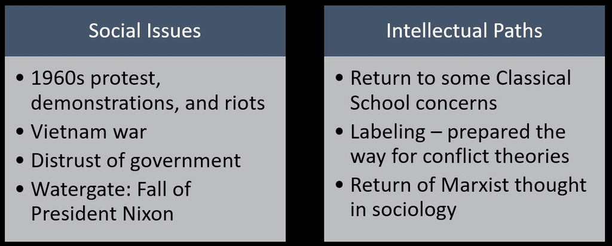

# Pluralist conflict perspectives

## Common elements

- Power and its use are central
- Conflict emerges between groups attempting to exercise control over social issues
- Social issues = fields of combat
- The group that controls resources (money, land, political power) wins
- Law and law enforcement are seen as resource.
- Law embodies the values of those who create it

## Various contributors

- George Vold
- Austin Turk
- Richard Quinney
- Hubert Blalock

## George Vold

- Overlap of interests causes inter-group conflict
- Permanent inter-group conflict aimed at improving standing
- Conflict struggle over control of power mirrored in lawmaking, lawbreaking, and law enforcement
- Lack of power to influence lawmaking results in the criminalization of minority group behaviour

## Austin Turk

- Social order is a product of powerful groups attempting to control society
- Examined criminal designation in an authority–subject relationship
- Less sophisticated subjects more likely to interact with authorities
- Control over society exerted through:
  - Coercion or physical force.
  - Control of legal images (ie, proscriptive and procedural laws) and living time (ie, generational relay)
- High crime rates result when:
  - Physical coercion is most common form of control
  - Controlling group is more powerful

## Richard Quinney

- Questioned the definitions of crime and the legal process
- Integrative approach (i.e., incorporated ideas from differential association, social learning, and labeling)
- Rejected the idea that scientific researchers worked with data representing the real world. He argued reality is what we perceive it to be.
- Crime = product of reaction
- Reaction of authorities is the most important as they have the political power to define crime and criminals.
- Crime, then, is the product of legal definitions constructed through the exercise of political power

## Hubert Blalock’s “power-threat” theory

- Emphasized importance of race and national origin
- Political control and/or violence used by white people to deal with challenges to their dominance
- Challenges arise when minority group grow enough
- Challenges to authority are answered by increasing discrimination through:
  - Restriction of political rights of minority
  - Increase of symbolic forms of segregation
  - Creation of threat-oriented ideological system

# Radical, Marxist conflict

## Common elements

- Positions range from political anarchism, Marxism, economic materialism, value diversity, and left realism.
- Ruling class:
  - controls society’ resources
  - Uses law as a means of control:
    - Creating laws emphasizing the behaviors of the lower classes
    - Encouraging a myth that law serves the interests of everyone

## Marxist Criminology

- Scarcity and unequal distribution of resources lead to Conflict in society
- Inequality creates a conflict between groups with and without power
- Two economic classes of society:
  - The proletariat (the working class)
  - The dominant bourgeoisie (the nonworking owners of wealth)
- Working class is:
  - Exploited by dominant class
  - Made to believe that capitalist structure was in their interest.
  - Motivated to revel when it realizes this is not true

## Steven Spitzer (1975) –Problem populations

- Surplus labour is necessary for capitalism
- Guarantees low wages because of competition for jobs
- Too much surplus labor creates problems
  - Expense of caring for them
  - Danger of revolt
- Types of surplus labor in relation to need for control:
  - Social Junk – less expensive, low threat (refuse to work or school, retreat to drugs, etc)
  - Social Dynamite – expensive, high threat (poor stealing from rich, anti-capitalist activists, etc)

## Major concepts in radical explanations of crime

- Social Class – created to separate people
- Political Economy – class tied to economic inequality
- Family Disorganization – product of inequality & reproduction of workplace relations in the home
- Economic Conditions – artificial unemployment yields necessity of control actions
- Surplus Value – decreasing cost of production yields increasing product value (property crime)

## Left Realism

- Emerged from criticism to radical and Marxist explanations for being too simplistic
- Aims to translate radical ideas into realistic social policy
- Realists recognize the presence of crime in socialist countries

## Anarchist Criminology

- Opposed to hierarchies in all their forms
- Views authorities as agents of domination, serving one or several groups at the expense of others.
- Domination does not merely imply coercion but also structures of knowledge, perception, and understanding.
- Justice should be face-to-face, negotiated

# Rational Theories

## Overview

- Late 1970s and 1980s
- Outgrowth of victimization data
- Borrow from economic models of behavior
- More conservative criminology

## Sociald and Political Context

- Social Heritage
  - 1970s and 1980s period of conservative thought
  - Several world events made Americans feel threatened
  - Crime control and punitive policies
  - Offenders viewed as bad people that chose to commit crimes
- Intellectual Heritage
  - 1980s field was seen as stagnant
  - Rehabilitation pronounced dead, attention turned to effectiveness of police, corrections, etc.
  - Victimiaztion surveys

## Major Rational Theories

- Routine Activities (Cohen & Felson)
- Lifestyle Theory (Hindelang, Garofalo, & Gottfredson)
- Rational Choice Theory (Cornish & Clark)

## Routine Activities Theory

- Volume of criminal offenses is related to normal everyday patterns of interaction
- Work, leisure, school, errands, socializing
- Offenders disproportionately find victims in certain settings
- 3 elements of a crime
  - Likely offender
  - Suitable target
  - Absence of a capable guardian

## Routine Activities

- Crime not related to social and cultural conditions
- Crime rates rise with:
  - increase in number of suitable victims
  - absence of protectors
- Individuals are more likely to be victimized:
  - the more they associate w/ or come in contact w/ members of demographic groups containing a greater number of offenders

## Lifestyle Theory

- Victims & offenders share similar demongraphic characteristics.
- Demographic characteristics not causal, but indicators of:
  - constraints (structural, economic, family, legal)
  - expectations (roles, duties, schedules)
- Same people often alternate between offender & victim
- Lifestyle patterns are determined by adaptations (individual & subcultural) to structural constraints & role expectations

## Rational Choice Theory

- Crime is a way to meet basic needs
  - Usually monetary, usually property crime
- Rationality is a decision-making process
  - What opportunities exist?
  - What are the potential costs of action?
  - What are the anticipated benefits?
- Bounded rationality

## Rational Choice Theory

- Involvement decisions
  - Is it worthwhile? Are risks reasonable? or Pass up opportunity?
- Event decisions
  - Tactics (methods) are acceptable, easy enough –helps to justify involvement
- Details can vary by type of crime – part reason of why offenders specialize

# Content review

## Key concepts

- The Conflict Continuum of Social Groups
- Surplus labour
- Likely offender
- Suitable target
- Absence of a capable guardian
- Bounded rationality
- Involvement decisions
- Event decisions